# beatochess no. 02 (April 2024)

Beat Neuenschwander, email: neuenschwander.beat@gmail.com

In this issue you find

- a recent study published in *Problem Paradise*
- five original studies
- and comments on and revisions of studies by Zakhodyakin, This continues the work started in **beatochess no. 01**.

# New study

Published in: **Problem Paradise** no. 105 (vol. 27), January-March 2024.

File: Neuenschwander-2024-ProblemParadise105.pgn

> Comment by Ryo Shiomi (editor): “The starting position looks quite complicated, but after the variation we reach the position with a clear-cut theme, where the WB’s corner to corner movement saves the game. Fantastic!”

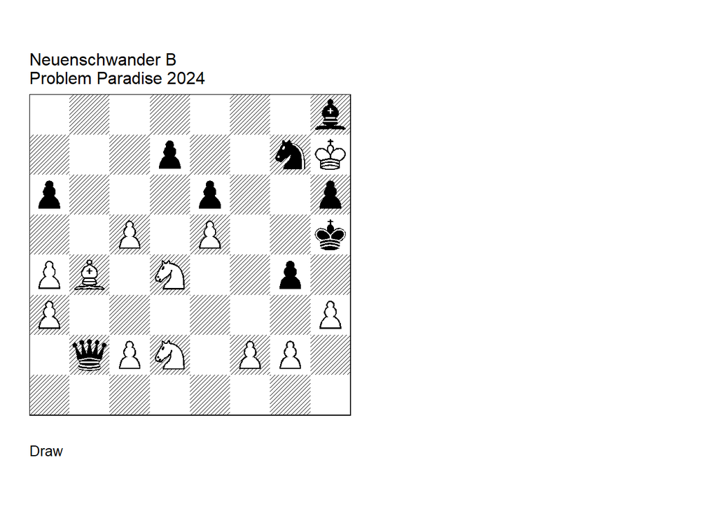

GBR: =3045.86h7h5 FEN: 7b/3p2nK/p3p2p/2P1P2k/PB1N2p1/P6P/1qPN1PP1/8 w - - 0 1

**1. c6!** (1. Ne4? Qxd4 -+) **1… dxc6** (1… gxh3 2. c7 hxg2 3. N2f3) **2. Ne4 Nf5** (2… Qxd4? 3. Ng3+ Kg5 4. Be7+ Kf4 5. Ne2+) **3. Nxf5 exf5 4. Ng3+ Kg5 5. h4+ Kf4 6. Bd6 Bxe5** (6… Qb7+ 7. Kxh8 Qc8+ 8. Kg7 Qd7+ 9. Kg6 Qe8+ 10. Kg7 = ) **7. Bf8 Qb7+ 8. Kg6 Bc7 9. Bg7! Threatens perpetual check with Ne2+ and Nc3+ etc. 9… Ba5 10. Ba1! Threatens perpetual check with Nh5+ and Nf6+ etc. 10… Bd8 11. Bh8!** (11. Bg7? Qe7 12. Nh5+ Ke4 13. Nf6+ Kd4 14. Ng8+ Qxg7+ 15. Kxg7 Bxh4 -+) **11… Ba5** (11… Qe7 12. Nh5+ Ke4 13. Nf6+ Kd4 (13… Qxf6+ 14. Bxf6 Bxf6 15. Kxf6 =) 14. Ng8+ =) **12. Ba1! Bd8 13. Bh8! positional draw 1/2-1/2**.

# Five original studies

For the studies in this section, I got some inspiration when looking at studies by Zakhodyakin.

Date: 2024, April 1

Files: BN-beatochess2024-1.pgn BN-beatochess2024-2.pgn

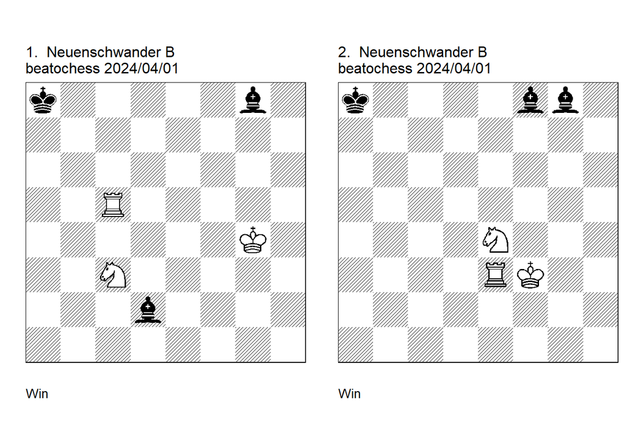

GBR: +0161.00g4a8 FEN: k5b1/8/8/2R5/6K1/2N5/3b4/8 w - - 0 1

**1. 1. Ne4 Be6+ 2. Kf3 Bb4** (2… Be1 3. Rc1 Bh4 (3… Ba5 4. Ra1) 4. Rh1 Be7 5. Rh8+) **3. Rb5 Bf8 4. Re5 Bd7** (4… Bf7 5. Rf5) **5. Rd5 1-0**.

GBR: +0161.00f3a8 FEN: k4bb1/8/8/8/4N3/4RK2/8/8 w - - 0 1

**2. 1. Rd3 Be7 2. Rd7 Bh4 3. Kf4 Kb8** (3… Bb3 4. Rh7 Be1 5. Rh1) **4. Ke5 Bc4 5. Kd6 Bf1 6. Rg7 1-0**.

Date: 2024, April 2

File: BN-beatochess2024-3.pgn

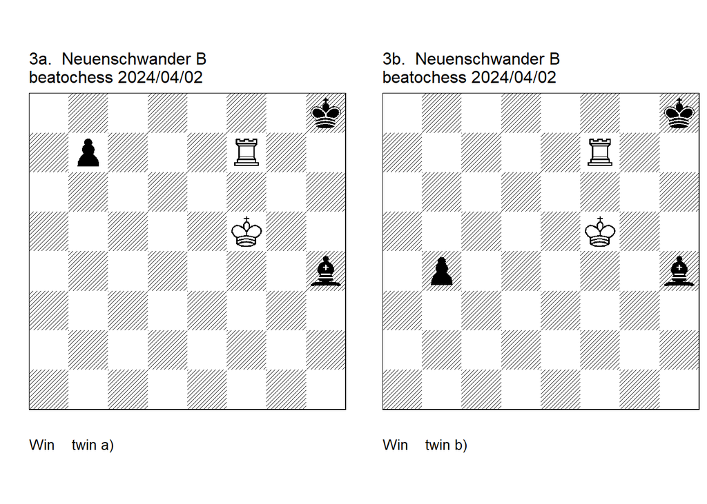

GBR: +0130.01f5h8 FEN: 7k/1p3R2/8/5K2/7b/8/8/8 w - - 0 1

**3a. 1. Rc7!** ( Try: 1. Kg6? Kg8 2. Rf4 Bd8 3. Rd4 Bb6 4. Rd6 Ba5) **1… Kg8 2. Rc4!** (2. Kg6? Kf8 3. Rc4 Bd8) **2… Be1** (2… Be7 3. Kg6 b5 (3… Kf8 4. Rc8+) 4. Rc8+ Bf8 5. Rb8) (2… Bf2 3. Kg6 Kf8 4. Rf4+) **3. Kg6 Kf8 4. Rf4+ Kg8 5. Re4 1-0**.

GBR: +0130.01f5h8 FEN: 7k/5R2/8/5K2/1p5b/8/8/8 w - - 0 1

**3b. 1. Kg6!** ( Try: 1. Rc7? Kg8 2. Rc4 Be1! 3. Kg6 Kf8 4. Rf4+ Ke7! 5. Re4+ Kd6 6. Rxe1) **1… Kg8 2. Rf4! Bg3 3. Rg4 Be5** (3… Bd6 4. Rd4) (3… Bc7 4. Rc4) (3… Bh2 4. Kf6+ Kf8 5. Rh4) (3… Be1 4. Re4) (3… Bf2 4. Rxb4 Bg3 5. Rg4 Bf2 6. Ra4 Kf8 7. Rf4+) **4. Re4 1-0**.

Date: 2024, April 26

File: BN-beatochess2024-4.pgn

Date: 2024, April 30

File: BN-beatochess2024-5.pgn

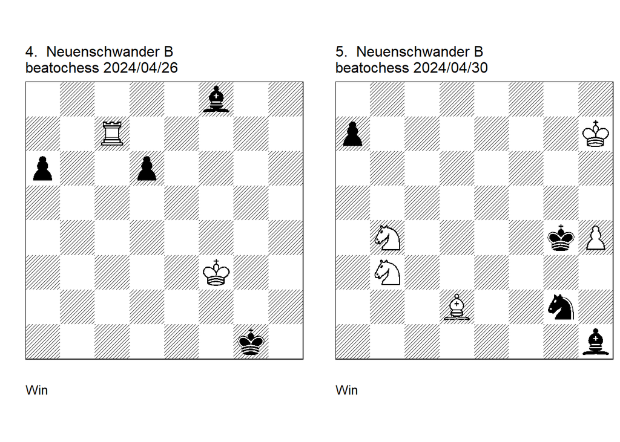

GBR: +0130.02f3g1 FEN: 5b2/2R5/p2p4/8/8/5K2/8/6k1 w - - 0 1

**4. 1. Rf7!** (1. Kg3? Bh6! =) (1. Rb7? d5! =) (1. Rd7? d5! =) **1… Bh6 2. Rb7!** (2. Rh7? Bc1! =) **2… d5** (2… a5 3. Rb8! a4 (3… Bd2 4. Rb1+ Kh2 5. Rb2) 4. Rg8+ Kf1 5. Rh8) (2… Bf8 3. Kg3 Kf1 4. Rf7+) **3. Rb6!** (3. Rb8? d4! 4. Rg8+ Kf1 5. Rh8 Be3 =) **3… Bf8 4. Kg3 Kf1 5. Rf6+ 1-0**.

GBR: +0045.11h7g4 FEN: 8/p6K/8/8/1N4kP/1N6/3B2n1/7b w - - 0 1

**5. 1. Nd3 Nxh4** (1… Kxh4 2. Nf2) **2. Nf2+ Kf3 3. Nxh1 Kg2 4. Nd4** (4. Be1? Nf3) **4… Kxh1** (4… Nf3 5. Nxf3 Kxf3 6. Be1 a5 7. Ng3) **5. Bg5! Ng2 6. Nf3 a5 7. Kg6 a4 8. Kf5 a3 9. Ke4 a2 10. Bf6 1-0**.

# Comments and revisions

## Studies by Zakhodyakin (continued)

### +0302.33c2d5 (1939). Cook, correction

Date: 2024, April 3

File: Zakhodyakin1939.pgn

**Study no. 60, 61** (Table 1 in beatochess-01)

Garcia’s correction does not work due to **1.. Kxc3**.

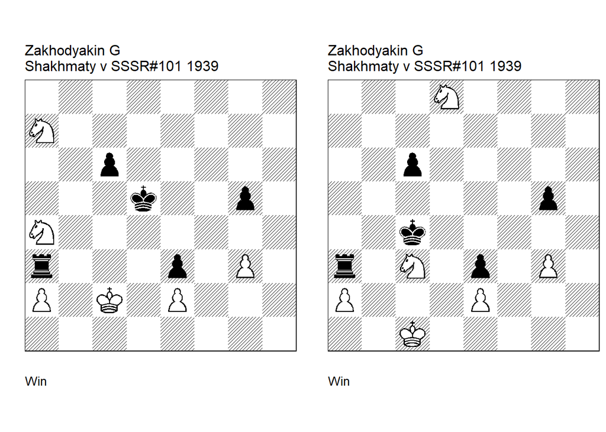

GBR: +0302.33c2d5 FEN: 8/N7/2p5/3k2p1/N7/r3p1P1/P1K1P3/8 w - - 0 1

**Shakhmaty v SSSR/7. U3: Garcia=M Estudios Artisticos de Ajedrez - XI-97 2012. 1. Nc3+ Kc4** (1… Kc5! cook MG 2. Nc8 Kd4) **2. Nxc6 Rxc3+ 3. Kb2 g4 4. Na5+ Kd4** (4… Kb4 5. a3+ Rxa3 6. Nc6+ Ka4 7. Nd4) **5. Nb3+ Kc4 6. Nc5! Kd4** (6… Kb4 7. Na6+ Kc4 8. Nc7) **7. Ne6+ Kc4 8. Nc7 Kd4** (8… Kb4 main 9. Nd5+ Kc4 10. Nxc3) **9. Nb5+ Kc4 10. Nxc3 1-0**.

GBR: +0302.33c1c4 FEN: 3N4/8/2p5/6p1/2k5/r1N1p1P1/P3P3/2K5 w - - 0 1

**Shakhmaty v SSSR/7. correction: Garcia=M Estudios Artisticos de Ajedrez - XI-97 2012. U3: Neuenschwander=B beatochess 03/04/2024. 1. Nxc6 Rxc3+** (1… Kxc3 -+ cook BN ) **2. Kb2 g4 3. Na5+ Kd4** (3… Kb4 4. a3+ Rxa3 5. Nc6+ Ka4 6. Nd4) **4. Nb3+ Kc4 5. Nc5! Kd4** (5… Kb4 6. Na6+ Kc4 7. Nc7) **6. Ne6+ Kc4 7. Nc7 Kd4** (7… Kb4 main 8. Nd5+ Kc4 9. Nxc3) **8. Nb5+ Kc4 9. Nxc3 1-0**.

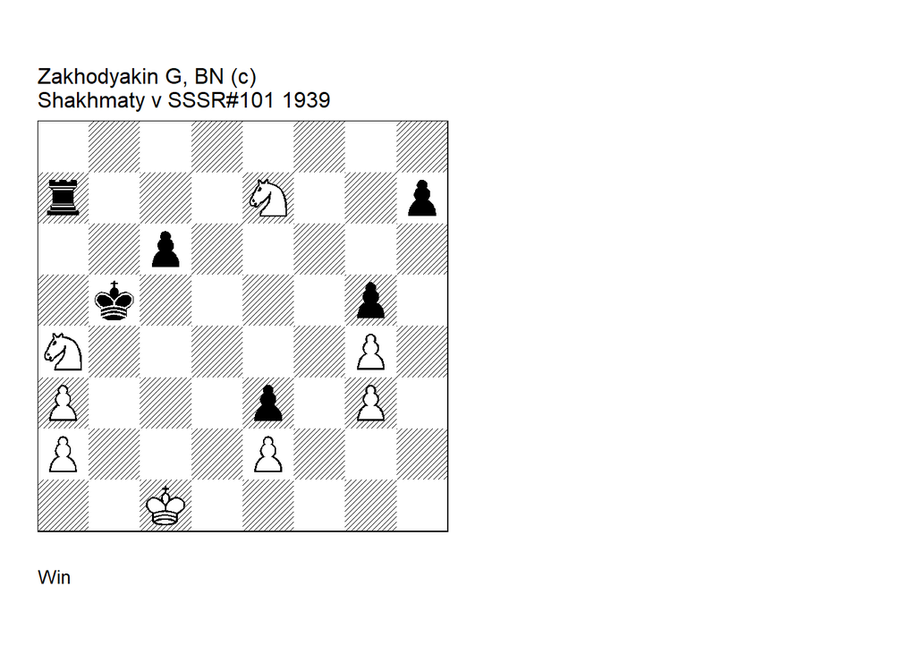

GBR: +0302.54c1b5 FEN: 8/r3N2p/2p5/1k4p1/N5P1/P3p1P1/P3P3/2K5 w - - 0 1

**correction: Neuenschwander=B beatochess 03/04/2024. 1. Nc3+ Kc4 2. Nxc6 Rxa3 3. Kc2!!** (3. Nd1? Rxa2 4. Nxe3+ Kc3 5. Nd5+ Kc4 6. e4 Ra3) (3. Kb2 Rxc3 4. Ne7 (4. Na5+? Kb4 5. a3+ Rxa3 6. Nc6+ Ka4 7. Nd4 h6) 4… Kd4 5. Nf5+ Kc4) **3… Rxc3+ 4. Kb2 h6 5. Na5+ Kd4** (5… Kb4 6. a3+! Rxa3 7. Nc6+ Ka4 8. Nd4! ) **6. Nb3+ Kc4 7. Nc5! Kd4** (7… Kb4 8. Na6+ Kc4 9. Nc7!) **8. Ne6+ Kc4 9. Nc7! Kd4** (9… Kb4 10. Nd5+) **10. Nb5+ 1-0**.

### =0302.03d1c5 (1948). Correction

Date: 2024, April 4

File: Zakhodyakin1948a.pgn

**Study no. 70** (Table 1 in beatochess-01)

I needed three more pawns to save this study.

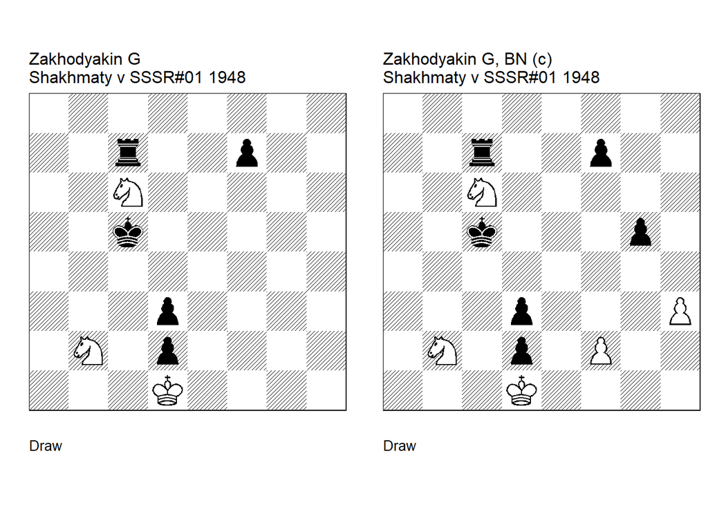

GBR: =0302.03d1c5 FEN: 8/2r2p2/2N5/2k5/8/3p4/1N1p4/3K4 w - - 0 1

**Shakhmaty v SSSR/1. U3: Shakhmaty v SSSR/3 1957. 1. Ne5 Kd4! 2. Nf3+!** (2. Nexd3? Ke3) **2… Kc3!** (2… Ke3 3. Nxd2) **3. Na4+ Kb4 4. Nb6! Kc5 5. Na4+ Kb5 6. Nb2! Rc1+ 7. Kxd2 Rc2+ 8. Kxd3 Rxb2 9. Ng5! Rf2** (9… f6 10. Ne4!) (9… f5 10. Ne6!) **10. Ne4! Rf3+ 11. Ke2 Rf4 12. Ke3 Rf1 13. Ke2! Rf4** ( 13… Rg1! cook 14. Nd6+ Kc5 15. Nxf7 Rg6 16. Kd3 Kd5 17. Ke3 Re6+ 18. Kd3 Rf6 19. Ng5 Rf5 20. Nh7 Kd6 21. Kd4 Ke7! 22. Ke4 Ke6 23. Kd4 Kf7 24. Ke4 Kg6) **14. Ke3 1/2-1/2**.

GBR: =0302.24d1c5 FEN: 8/2r2p2/2N5/2k3p1/8/3p3P/1N1p1P2/3K4 w - - 0 1

**correction: Neuenschwander=B beatochess 04/04/2024. 1. Ne5 Kd4 2. Nf3+ Kc3 3. Na4+ Kb4** ( 3… Kb3 4. Nb6) **4. Nb6!** (4. Nb2? Rc2! 5. Nxd3+ Kc3 6. Ke2 Rc1! 7. Nxd2 Rc2) **4… Kc5 5. Na4+ Kb5 6. Nb2 Rc1+ 7. Kxd2 Rc2+ 8. Kxd3 Rxb2 9. Nxg5** (9. Ke3 f6) **9… Rxf2 10. Ne4 Rf1 11. Ke2 Rf4 12. Ke3 Rf1 13. Ke2 1/2-1/2**.

### =0002.02c8e8 (1949). Correction

Date: 2024, April 4

File: Zakhodyakin1949.pgn

**Study no. 71** (Table 1 in beatochess-01)

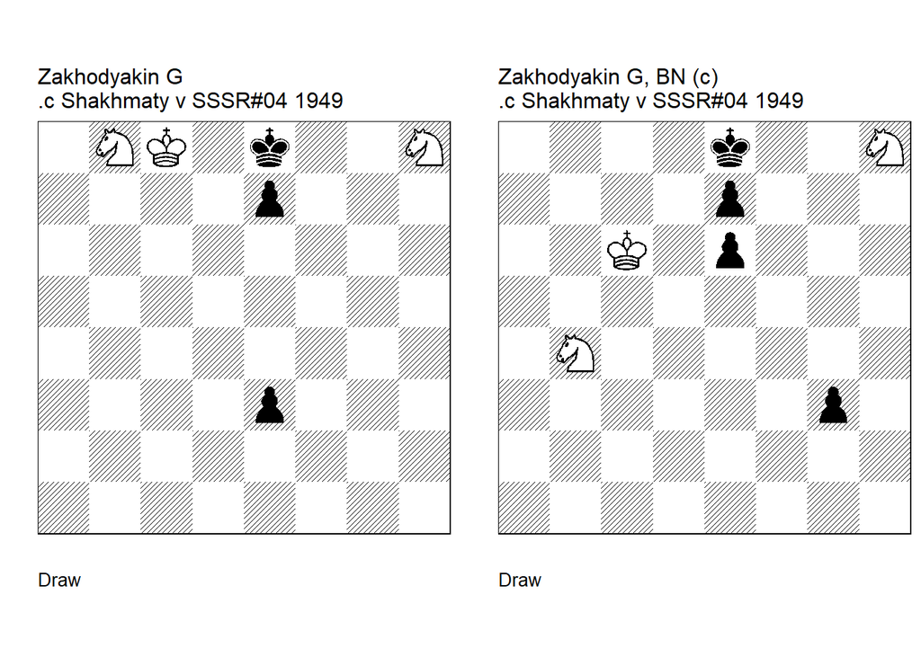

GBR: =0002.02c8e8 FEN: 1NK1k2N/4p3/8/8/8/4p3/8/8 w - - 0 1

**Shakhmaty v SSSR/1. U2: Beasley=J HHdbIII 44615 3-2-2002. 1. Na6! e2 2. Nc7+ Kf8 3. Ne6+** (3. Ng6+! cook JB ) **3… Kg8 4. Nf7! e1=Q** (4… Kxf7 5. Ng5+) **5. Nfg5! Qd2 eg 6. Kc7 Qd5 7. Kb6 Qc4 8. Kb7 1/2-1/2**.

GBR: =0002.03c6e8 FEN: 4k2N/4p3/2K1p3/8/1N6/6p1/8/8 w - - 0 1

**correction: Neuenschwander=B beatochess 04/04/2024. 1. Na6! g2 2. Nc7+ Kf8** (2… Kd8 3. Nxe6+ Kc8 4. Ng6 g1=Q 5. Nxe7+ =) **3. Nxe6+ Kg8 4. Nf7! g1=Q 5. Nfg5 1/2-1/2**.

### +3200.33g1h4 (1967). Version

Date: 2024, April 7

File: Zakhodyakin1967.pgn

**Study no. 107** (Table 1 in beatochess-01)

The RRvsQ ending seems difficult to fix: the white rooks are simply to strong given the bad position of the black king. In addition to the cook on move 1, there is also the alternative win **4.Rg1** in the main line.

The version shows the theme (luring the black queen to g7 and trapping it) with a white knight and rook.

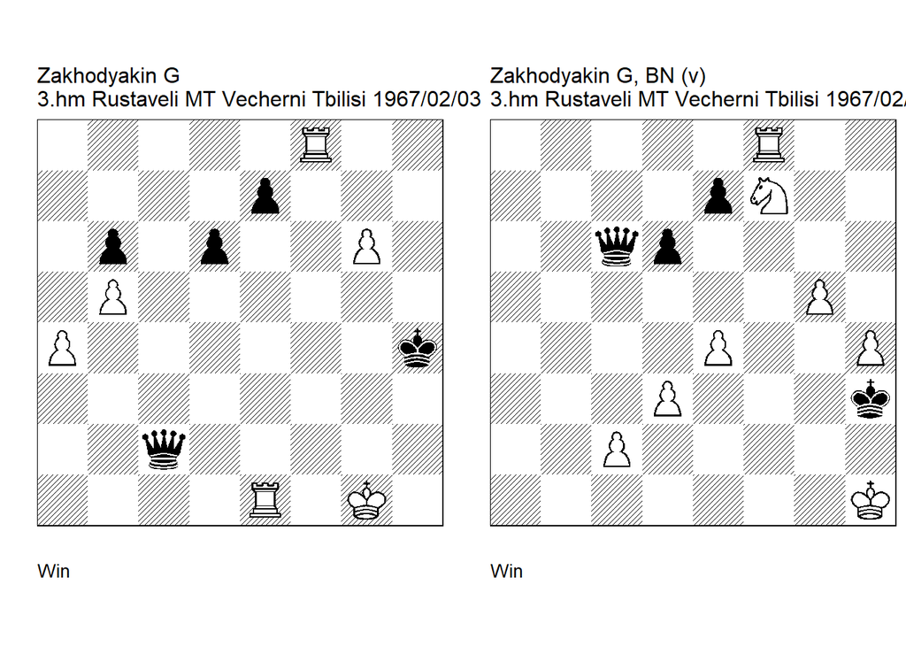

GBR: +3200.33g1h4 FEN: 5R2/4p3/1p1p2P1/1P6/P6k/8/2q5/4R1K1 w - - 0 1

**EG 00396. U1: Beasley=J HHdbIII 33057 3-2-2002 U2: Neuenschwander=B beatochess 07/04/2024. 1. g7** (1. Kh1! cook JB 1… Qc3 (1… Qxg6 2. Rh8+) 2. Re2 Qa1+ 3. Kh2) **1… Qg6+ 2. Kh1!** (2. Kf2? Qg3+ 3. Kf1 (3. Ke2 Qe5+ 4. Kd3 Qd5+ 5. Ke3 Qe5+ 6. Kf3 Qg3+) 3… Qxg7 4. Rf4+ Kh5) (2. Kh2? Qg3+ 3. Kh1 Qxe1+) **2… Qxg7 3. Rf4+ Kh5 4. Rf5+** (4. Rg1 cook BN 4… Qe5 5. Rfg4 Qd5+ 6. R1g2 Qf3 7. Rg3 Qf1+ 8. Rg1 Qf5 9. Rg5+ Qxg5 10. Rxg5+ Kxg5 11. a5) **4… Kh4 5. Ree5! dxe5 6. Rf2! 1-0**.

GBR: +3101.52h1h3 FEN: 5R2/4pN2/2qp4/6P1/4P2P/3P3k/2P5/7K w - - 0 1

**version: Neuenschwander=B beatochess 07/04/2024. 1. g6 Qc3** (1… Qxc2 2. Ng5+ Kg3 (2… Kxh4 3. Rf1!) 3. Rf3+ Kxh4 4. Rf1) **2. Ng5+ Kxh4** (2… Kg3 3. Rf1) **3. Nf3+** (3. Rf1? Kh5!) **3… Kh5** (3… Kg3 4. Ng1 Qg7 5. Rf3+! Kh4 6. Kh2) **4. g7! Qxg7 5. Rf5+ Kh6** (5… Kg4 6. Rg5+) **6. Ne5!! dxe5** (6… Qg3 7. Nf7+ Kh7 8. Rh5+ Kg6 9. Rg5+) (6… Qg8 7. Nf7+ Kh7 8. Rh5+ Kg6 9. Rg5+) (6… Kh7 7. Rf7) (6… e6 7. Nf7+ Kh7 8. Rh5+ Kg8 9. Rg5) (6… Qh7 7. Rf2) (6… Qh8 7. Nf7+) **7. Rf2 1-0**.

### =3002.10c2h7 (1972). Version

Date: 2024, April 9

File: Zakhodyakin1972a.pgn

**Study no. 126** (Table 1 in beatochess-01)

Beasley’s cook can be fixed by changing the main line to **3… Qg4 4. Nhf5 Qf3 5. Kd2 Qb3 6. Ke2**. This is the line given in my version, which has a bit more content (two main lines).

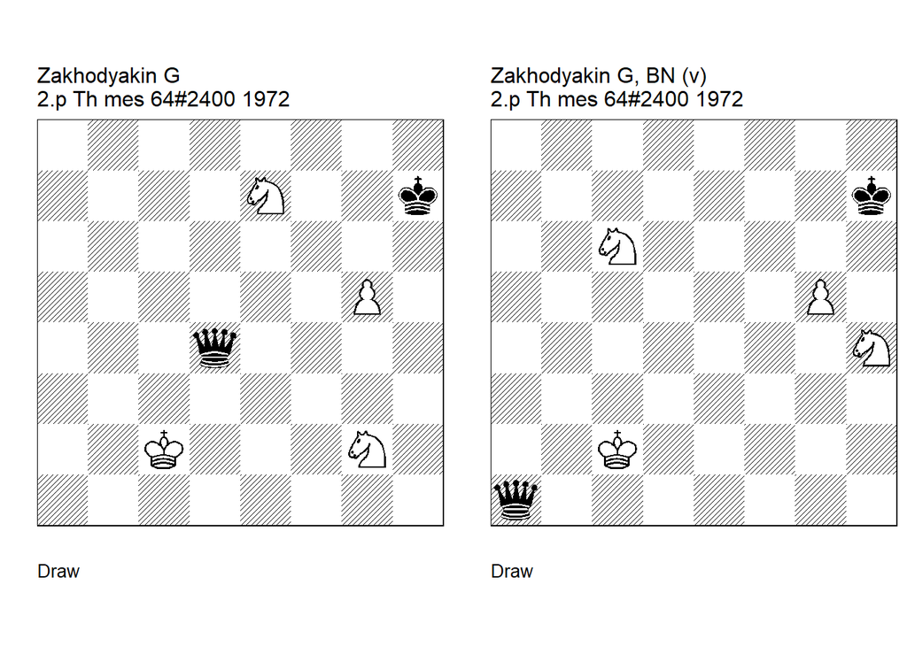

GBR: =3002.10c2h7 FEN: 8/4N2k/8/6P1/3q4/8/2K3N1/8 w - - 0 1

**Th mes 64=66 Th mes 64/4-6 also Chess Life & Review 0541 Chess Life & Review=10 Chess Life & Review/10 1972** (EG 02453) **. U2: Beasley=J HHdbIII 29359 3-2-2002. 1. g6+ Kh8** (1… Kg7 2. Nf5+) **2. g7+! Qxg7 3. Nh4! Qh7+ 4. Nhf5! Qh3! 5. Kd2!** (5. Nd4! cook JB ) **5… Qf3 6. Kc2! Kh7 7. Kd2 1/2-1/2**.

GBR: =3002.10c2h7 FEN: 8/7k/2N5/6P1/7N/8/2K5/q7 w - - 0 1

**version: Neuenschwander=B beatochess 09/04/2024. 1. g6+ Kh8 2. g7+ Kxg7** (2… Qxg7 main 3. Ne7! Qg4 (3… Qh7+ 4. Nhf5) 4. Nhf5 Qf3 5. Kd2! Qb3 6. Ke2!) **3. Nd4!** (3. Nf5+? Kf6 4. Nfd4 Qa3! 5. Kd2 Kg5!) **3… Kf6 4. Nhf3 1/2-1/2**.

### +0013.12c8a8 (1972). Correction

Date: 2024, April 10

File: Zakhodyakin1972b.pgn

**Study no. 125** (Table 1 in beatochess-01)

The correction requires two additional pawns, but it has a thematic try now.

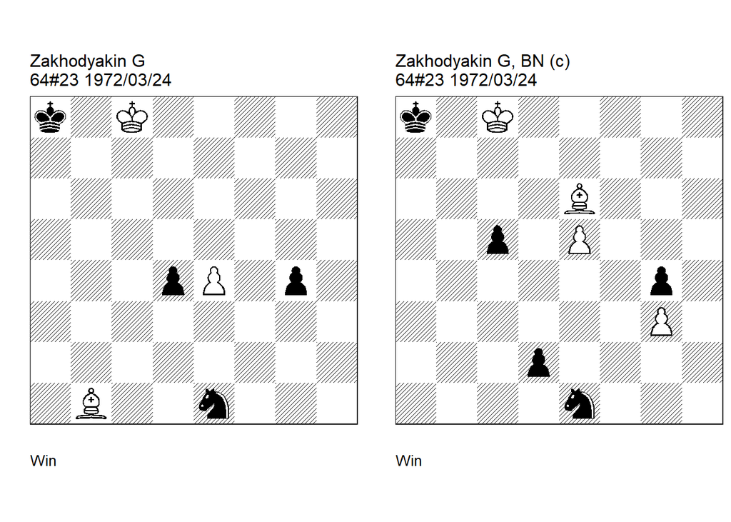

GBR: +0013.12c8a8 FEN: k1K5/8/8/8/3pP1p1/8/8/1B2n3 w - - 0 1

**64=12** (195) **. U3: Korolkov=V 64=9** (296) **1-3-1974. 1. e5 d3** (1… g3! cook VK 2. e6 Ka7! 3. e7 g2) **2. e6 d2 3. Bc2! Nxc2 4. e7 d1=Q 5. e8=Q Ka7 6. Qb5! 1-0**.

GBR: +0013.23c8a8 FEN: k1K5/8/4B3/2p1P3/6p1/6P1/3p4/4n3 w - - 0 1

**correction: Neuenschwander=B beatochess 10/04/2024. 1. Bb3!** (1. Bxg4? c4 2. e6 c3 3. Bd1 c2 4. Bxc2 Nxc2 5. e7 d1=Q 6. e8=Q Ka7 7. Qb5 Qg4+) **1… c4 2. Bd1!** (2. Ba4? Nf3 3. e6 Nd4 4. e7 Nf5 5. Kd8 Ng7 (5… Nxe7? is too slow ) 6. e8=Q Nxe8 7. Kxe8 Kb7 8. Kf7 Kb6 9. Kf6 Ka5 10. Bd1 Kb4 11. Ke5 Kc3) **2… c3 3. e6 c2 4. Bxc2 Nxc2 5. e7 d1=Q 6. e8=Q Ka7 7. Qb5!** (7. Qc6? Qf3 ( 7… Qb1 or ) ) **1-0**.

### =0011.01b7b4 (1980). Correction

Date: 2024, April 11

File: Zakhodyakin1980a.pgn

**Study no. 176** (Table 1 in beatochess-01)

The theoretical draw with the white bishop on b7, which cooks the original study, cannot be reached in the correction.

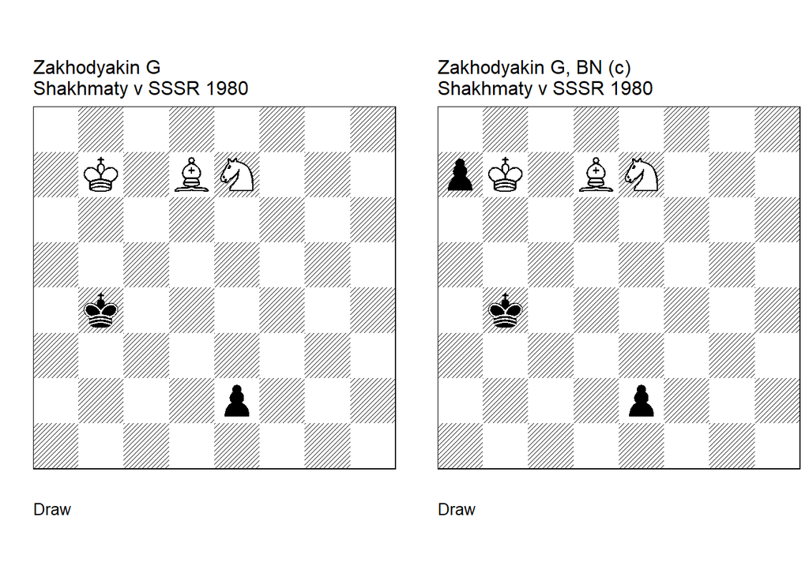

GBR: =0011.01b7b4 FEN: 8/1K1BN3/8/8/1k6/8/4p3/8 w - - 0 1

**Shakhmaty v SSSR/6. U2: Prigunov=V Shakhmaty v SSSR/7 1985. 1. Nd5+! Ka5!** (1… Kb3 2. Ba4+! Kxa4 3. Nc3+) **2. Ne7!** (2. Ka8! cook VP 2… e1=Q 3. Bc6) **2… e1=Q 3. Nc6+ Ka4** (3… Kb5 4. Ne5+!) **4. Nd4+! Ka5 5. Nc6+ 1/2-1/2**.

GBR: =0011.02b7b4 FEN: 8/pK1BN3/8/8/1k6/8/4p3/8 w - - 0 1

**correction: Neuenschwander=B 11/04/2024. 1. Nd5+ Ka5** (1… Kb3 2. Ba4+!) **2. Ne7!** (2. Kxa7? is one move too slow. White cannot reach the theoretical draw with the bishop on b7. 2… e1=Q 3. Bc6 Qf2+ (3… Qg1+? 4. Ka8 Qg8+ 5. Ka7 Qf7+ 6. Bb7) 4. Ka8 Qf8+ 5. Ka7 Qc5+ 6. Kb7 Qd6) **2… e1=Q 3. Nc6+ Ka4 4. Nd4+ Ka5 5. Nc6+ Kb5 6. Ne5+ Ka5 7. Nc6+ 1/2-1/2**.

### =3041.10g8h3 (1980). Modification

Date: 2024, April 11

File: Zakhodyakin1980b.pgn

**Study no. 181** (Table 1 in beatochess-01)

The modification shows the idea of the original study with a different material constellation.

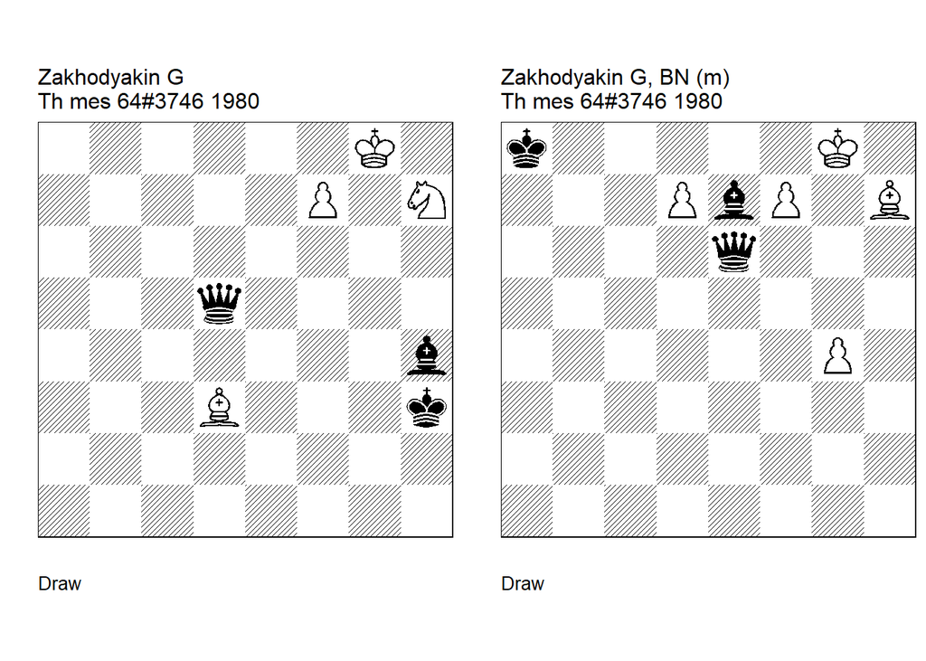

GBR: =3041.10g8h3 FEN: 6K1/5P1N/8/3q4/7b/3B3k/8/8 w - - 0 1

**Th mes 64=100 Th mes 64/10-12. U3: Pachman=V Th mes 64=103 8-9/1981 U3: Beasley=J HHdbIII 22304 3-2-2002. 1. Bf5+!** (1. Be4? Qa2 2. Bb1 Qg2+ 3. Kf8 Be1 4. Ke8 Bb4) **1… Kh2 2. Ng5! Bxg5 3. Be4! Qa2** (3… Qb3! cook JB 4. Bc2 Qg3 5. f8=Q Bh6+) **4. Bb1 Qg2! cook VP 5. Be4 Qg3 1/2-1/2**.

GBR: =3040.30g8a8 FEN: k5K1/3PbP1B/4q3/8/6P1/8/8/8 w - - 0 1

**modification: Neuenschwander=B beatochess 11/04/2024. 1. d8=Q+** (1. g5? Qxd7 ) (1. Bf5? Qd6) **1… Bxd8 2. Bf5** (2. g5? Be7 3. g6 Qc8+ 4. Kg7 Qf8 ) **2… Qc4 3. g5** (3. Bd3? Qxg4+) **3… Bxg5 4. Bd3 Qa2** (4… Qd5 5. Be4) **5. Bb1 Qb3 6. Bc2 Qe6 7. Bf5 1/2-1/2**.

### =3103.10a2g4 (1981). Correction

Date: 2024, April 11

File: Zakhodyakin1981a.pgn

**Study no. 199** (Table 1 in beatochess-01)

With the white rook on c2 the study is correct.

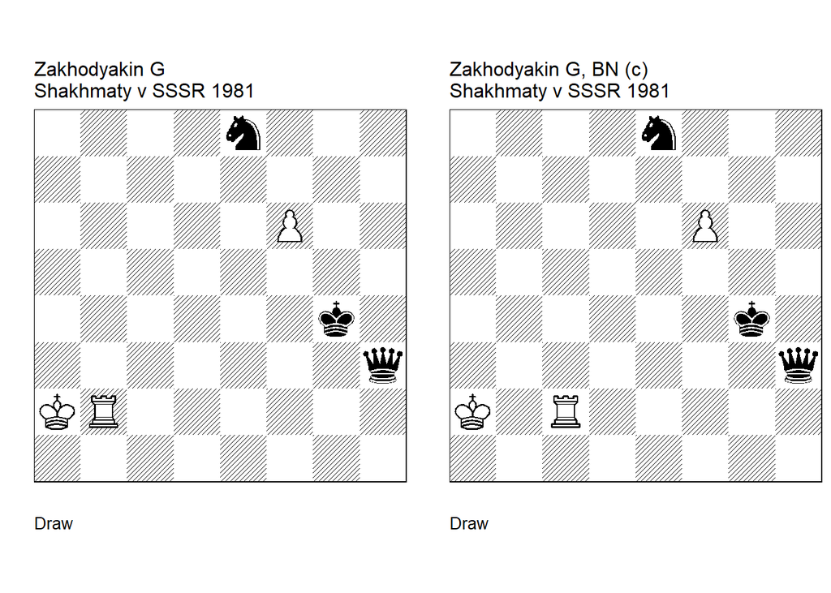

GBR: =3103.10a2g4 FEN: 4n3/8/5P2/8/6k1/7q/KR6/8 w - - 0 1

**Shakhmaty v SSSR/1. U2: Beasley=J HHdbIII 21035 3-2-2002. 1. f7 Qh8 2. Rg2+!** (2. Rf2? Nf6) (2. Rb8 Qh2+ 3. Ka3 Qd6+ 4. Ka4 (4. Rb4+! cook JB ) 4… Qd7+) **2… Kf3 3. Rg8! Qh2+ 4. Rg2! Qh8 5. Rg8 Qh2+ 6. Rg2 Qxg2+ 7. Ka3 1/2-1/2**.

GBR: =3103.10a2g4 FEN: 4n3/8/5P2/8/6k1/7q/K1R5/8 w - - 0 1

**Shakhmaty v SSSR/1. correction: Neuenschwander=B beatochess 11/04/2024 . 1. f7 Qh8 2. Rg2+** (2. Rc8? Qh2+ 3. Kb3 Qg3+ 4. Rc3 (4. Kb4 Qd6+) 4… Qb8+ 5. Kc2 Nd6) **2… Kf3 3. Rg8! Qh2+ 4. Rg2! Qh8 5. Rg8 Qh2+ 6. Rg2 Qxg2+ 7. Ka3 1/2-1/2**.

### =0040.12b3e4 (1982). Cook, correction

Date: 2024, April 12

File: Zakhodyakin1982a.pgn

**Study no. 210, 211** (Table 1 in beatochess-01)

Keith’s correction is incorrect due to **1… Bd3!** or **1… Bg2!**. The correction has a more natural starting position.

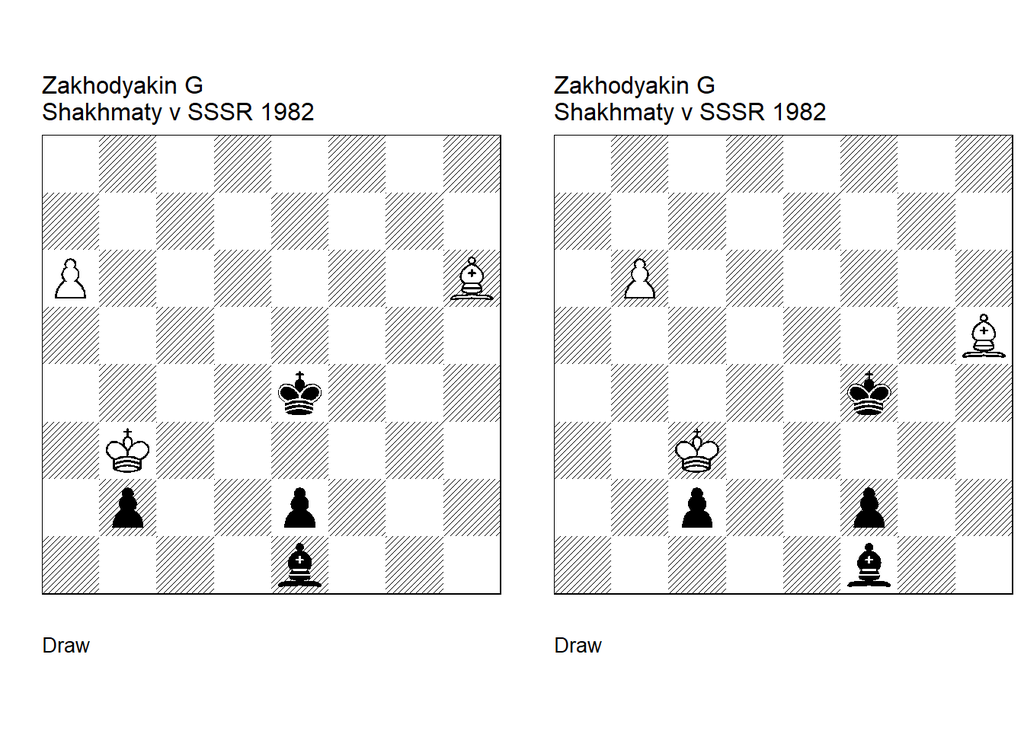

GBR: =0040.12b3e4 FEN: 8/8/P6B/8/4k3/1K6/1p2p3/4b3 w - - 0 1

**Shakhmaty v SSSR/12. U3: Isakov=V Shakhmaty v SSSR/2 1985 U3: Haworth=G Bleicher=E HHdbIV 50746 1-11-2009. 1. Kc2** (1. Kxb2? Bc3+) (1. Ka2? Kd3 2. a7 Kc2) **1… Ba5! 2. Bd2!** (2. a7? b1=Q+ 3. Kxb1 e1=Q+ 4. Bc1 Qb4+) **2… Bxd2 3. a7 b1=Q+** (3… Kd4! cook VI ) **4. Kxb1 e1=Q+ 5. Ka2 Qc1** (5… Kd4! cook VI 6. a8=Q Qe6+) (5… Kd3! cook GH/EB ) **6. a8=Q+ 1/2-1/2**.

GBR: =0040.12c3f4 FEN: 8/8/1P6/7B/5k2/2K5/2p2p2/5b2 w - - 0 1

**Shakhmaty v SSSR/12. correction: Keith=D EG=188 4/2012. U3 Neuenschwander=B beatochess 12/04/2024. 1. Kd2 Ba6** (1… Bd3 cook BN 2. Be2 (2. b7 f1=Q 3. b8=Q+ Kg5 4. Qe5+ Kh6) 2… c1=Q+ 3. Kxc1 Ke3! 4. b7 Kxe2) (1… Bg2 cook BN 2. Be2 Be4) **2. Be2 Bxe2 3. b7 c1=Q+ 4. Kxc1 f1=Q+ 5. Kb2 Qd1 6. b8=Q+ 1/2-1/2**.

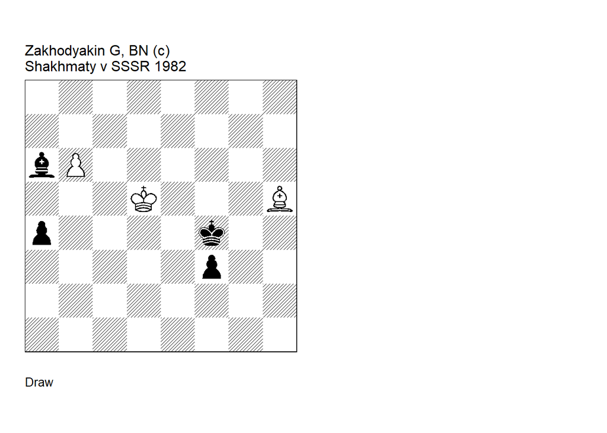

GBR: =0040.12d5f4 FEN: 8/8/bP6/3K3B/p4k2/5p2/8/8 w - - 0 1

**correction: Neuenschwander=B beatochess 12/04/2024. 1. Kd4!** (1. Bxf3? a3) **1… f2 2. Be2! a3** (2… Bxe2 3. b7 f1=Q 4. b8=Q+ = , e.g. 4… Kg4 5. Qg8+ Kh4 6. Qh7+ Kg3 7. Qg6+ Bg4 8. Qd3+) **3. Kc3 a2 4. Kb2 Bxe2 5. b7 a1=Q+ 6. Kxa1 f1=Q+ 7. Kb2 1/2-1/2**.

### =3101.01f3g7 (1982). Correction

Date: 2024, April 12

File: Zakhodyakin1982b.pgn

**Study no. 221** (Table 1 in beatochess-01)

There are many ways to a draw in the original study. The way to draw in the correction is narrow, with a few tries in the sidelines. The study keeps the highlight **4. Rg6!**, but the end is a bit different.

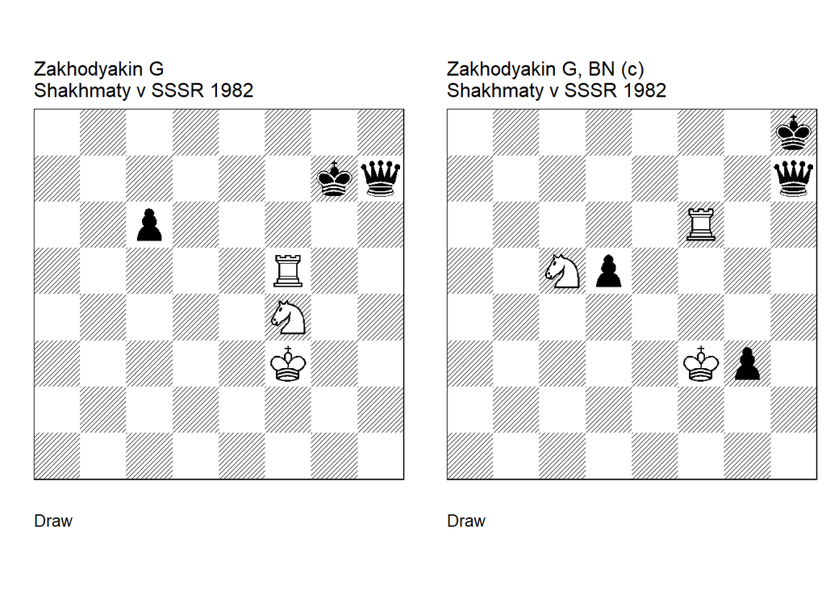

GBR: =3101.01f3g7 FEN: 8/6kq/2p5/5R2/5N2/5K2/8/8 w - - 0 1

**Shakhmaty v SSSR/9. U2: Beasley=J HHdbIII 20150 3-2-2002. 1. Ne6+ Kh6 2. Rf6+ Kh5 3. Rg6! Qd7 4. Nf4+** (4. Rg5+! cook JB 4… Kh4 5. Rg4+ Kh5 (5… Kh3? 6. Nf4+) 6. Rg5+) **4… Kh4 5. Ng2+ 1/2-1/2**.

GBR: =3101.02f3h8 FEN: 7k/7q/5R2/2Np4/8/5Kp1/8/8 w - - 0 1

**correction: Neuenschwander=B beatochess 12/04/2024. 1. Rf8+ Kg7 2. Ne6+ Kh6** ( 2… Kg6 3. Kxg3! (3. Nf4+? Kg5 4. Kxg3 Qh4+ 5. Kg2 (5. Kf3 Qh1+) 5… Qg4+ 6. Kf2 Qxf4+) 3… Qe7 4. Nf4+ Kg5 (4… Kg7 5. Rd8) (4… Kh7 5. Rh8+ Kg7 6. Rd8) 5. Nh3+ and Rf3 ) **3. Rf6+** (3. Kxg3 Qg6+) (3. Nf4 Qg7) (3. Rf4 Qd3+) **3… Kh5 4. Rg6!** (4. Nf4+ Kg5 (4… Kh4? 5. Rg6) 5. Rg6+ Kf5 6. Rxg3 Qh1+ is theoreatically lost ) **4… Qf7+** (4… Qxg6 5. Nf4+ Kg5 6. Nxg6 Kxg6 7. Kxg3) **5. Nf4+ Qxf4+ 6. Kxf4 Kxg6 7. Kxg3 1/2-1/2**.

### =3230.10a8b6 (1983). Correction

Date: 2024, April 13

File: Zakhodyakin1983a.pgn

**Study no. 233** (Table 1 in beatochess-01)

In addition to Harold’s cook towards the end, there is also the unfortunate cook **1. Ra5**. The correction improves the study: rook not en prise in the starting position, quiet first move, and some White tries.

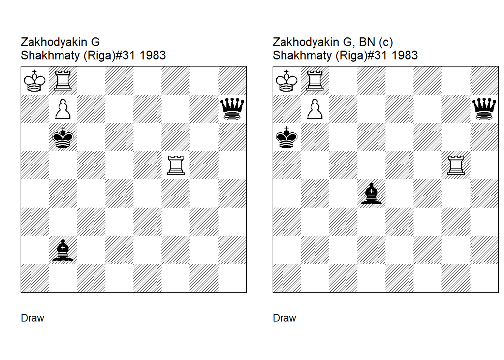

GBR: =3230.10a8b6 FEN: KR6/1P5q/1k6/5R2/8/8/1b6/8 w - - 0 1

**Shakhmaty** (Riga) **=21 Shakhmaty** (Riga) **/11. U2: Van, der, Heijden=H HHdbIV 51756 3-1-2010 U1: Neuenschwander=B beatochess 13/04/2024. 1. Rb5+!** (1. Ra5 cook BN ) **1… Kxb5 2. Rh8! Qe4 3. Rh4! Qc6 4. Rh6 Qf3 5. Rh3 Qd5 6. Rh5** (6. Rb3+! cook HH ) **6… Be5 7. Rxe5 1/2-1/2**.

GBR: =3230.10a8b6 FEN: KR6/1P5q/k7/6R1/3b4/8/8/8 w - - 0 1

**correction: Neuenschwander=B beatochess 13/04/2024. 1. Rb5!** (1. Rg4? Qe7! 2. Rxd4 (2. Rg6+ Bf6) 2… Qa3 3. Rd3 (3. Rg8 Kb6+ 4. Kb8 Qa7+ 5. Kc8 Qxb7+ 6. Kd8 Qb8+) 3… Qa5 (3… Qxd3? 4. Re8) 4. Rf8 Kb6+ 5. Kb8 Qa7+ 6. Kc8 Qxb7+ 7. Kd8 Qc7+ 8. Ke8 Qe5+ 9. Kd8 Qg5+ 10. Kc8 Qc5+ 11. Kd7 Qb5+) (1. Rd5) **1… Kxb5 2. Rh8!** (2. Re8 Qh1!) **2… Qe4 3. Rh4 Qf3 4. Rh3!** (4. Rxd4? Qa3+! 5. Kb8 Kb6) **4… Qc6 5. Rh6 Qg2 6. Rh2 Qd5 7. Rh5 1/2-1/2**.

### +0160.10e4f1 (1983). Cook, Correction

Date: 2024, April 14

File: Zakhodyakin1983b.pgn

**Study no. 223** (Table 1 in beatochess-01)

White dominates the black bishop after the somewhat paradoxical **4. Kd2** (moving the king away and giving Black more space). Unfortunately, **4. Rb2** also wins. The additional black pawn on f6 saves the study.

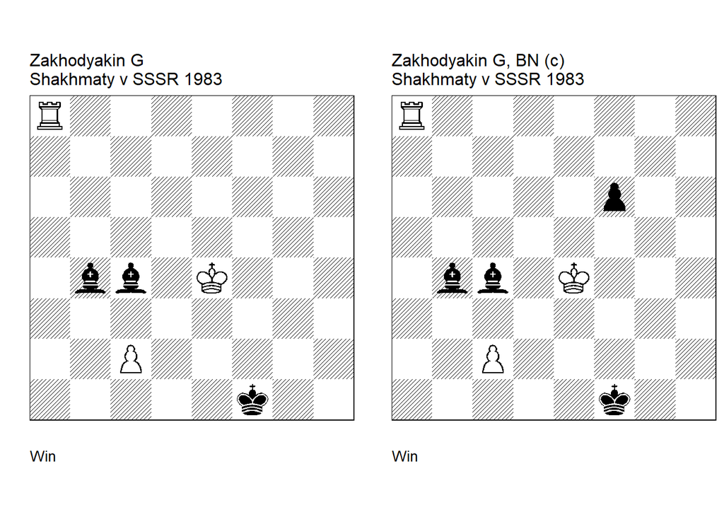

GBR: +0160.10e4f1 FEN: R7/8/8/8/1bb1K3/8/2P5/5k2 w - - 0 1

**Shakhmaty v SSSR/9. U2: Neuenschwander=B beatchess 14/04/2024. 1. Ra4 Bf7 2. Rxb4 Bg6+ 3. Ke3 Bxc2 4. Kd2** (4. Rb2 cook BN 4… Bh7 5. Rf2+ Kg1 6. Kf3) **4… Bh7 5. Rh4 Bg8 6. Rf4+ 1-0**.

GBR: +0160.11e4f1 FEN: R7/8/5p2/8/1bb1K3/8/2P5/5k2 w - - 0 1

**correction: Neuenschwander=B beatochess 14/04/2024. 1. Ra4 Bf7** (1… f5+ 2. Kd4!) **2. Rxb4 Bg6+ 3. Ke3 Bxc2 4. Kd2** (4. Rb2? Bd1! (4… Ba4 or ) 5. Rb1 Ke1 6. Kd3 f5) **4… Bh7 5. Rh4 Bg8 6. Rf4+ 1-0**.

### =0031.11d7h2 (1986). Correction

Date: 2024, April 14

File: Zakhodyakin1986a.pgn

**Study no. 247** (Table 1 in beatochess-01)

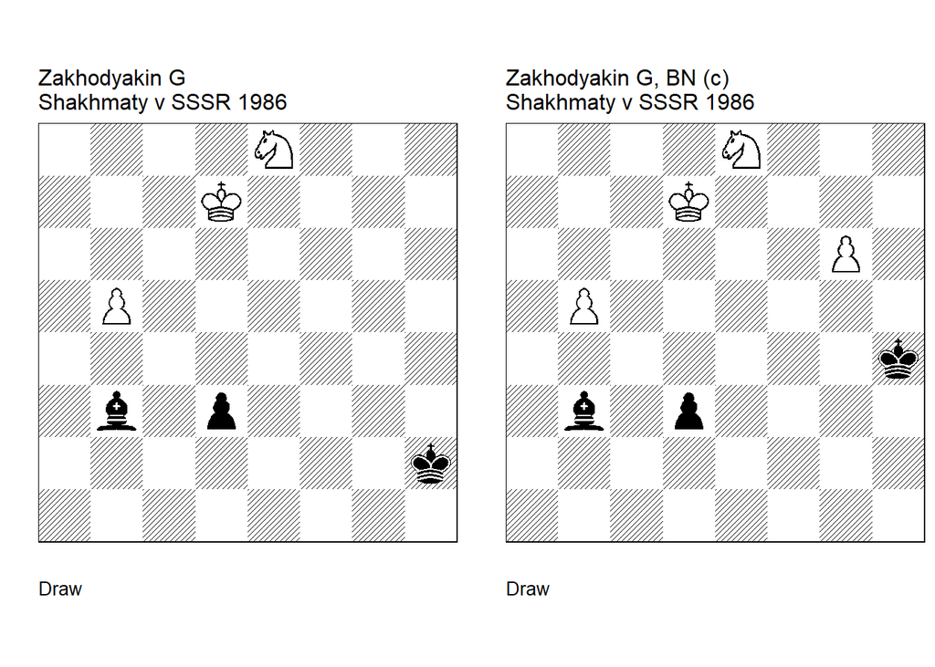

GBR: =0031.11d7h2 FEN: 4N3/3K4/8/1P6/8/1b1p4/7k/8 w - - 0 1

**Shakhmaty v SSSR/6. U3: Bolshagin=V Shakhmaty v SSSR/11 1986. 1. Nf6! d2** ( 1… Ba4 2. Kd6! Bxb5 3. Ne4! Kg2 4. Kc5) **2. Ng4+ Kg3 3. Ne3 Kf3 4. b6 Kxe3 5. b7 d1=Q+ 6. Ke7 Qd4** (6… Be6! cook VB 7. b8=Q Qd7+ 8. Kf6 Qf7+ 9. Kg5 (9. Ke5 Qf4+) 9… Qg7+ 10. Kh5 Bf7+ 11. Kh4 Qh6+ 12. Kg3 (12. Kg4 Be6+ 13. Kg3 Qh3 ) 12… Qg5+ 13. Kh3 Be6+ 14. Kh2 Qh4+ 15. Kg2 Qf2+ 16. Kh1 Bd5 ) **7. b8=Q 1/2-1/2**.

**correction: Neuenschwander=B beatochess 14/04/2024. 1. Nd6** (1. Ng7? Kg4!) **1… d2 2. Nf5+ Kg4 3. Ne3+ Kf3 4. b6 Kxe3 5. b7 d1=Q+ 6. Ke7 1/2-1/2**.

### +0170.01e6h1 (1983). Correction

Date: 2024, April 15

File: Zakhodyakin1983c.pgn

**Study no. 224** (Table 1 in beatochess-01)

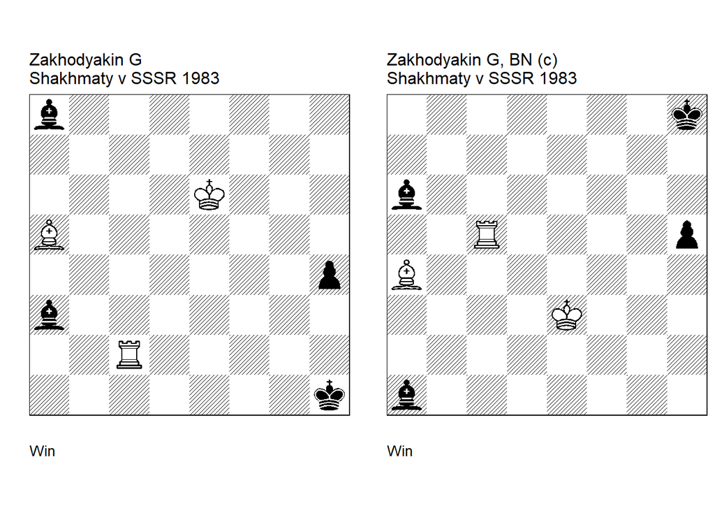

GBR: +0170.01e6h1 FEN: b7/8/4K3/B7/7p/b7/2R5/7k w - - 0 1

**Shakhmaty v SSSR/3. U3: Nikoronov=A Shakhmaty v SSSR/12 1983. 1. Rc3 Bb2 2. Rd3! Bg7** (2… Bg2 3. Bc7 Kg1 4. Rd1+ Bf1 5. Bb6+) **3. Rd1+ Kh2** (3… Kg2! cook AN 4. Rd8! Bf3 5. Rg8 Bg4+! 6. Kd5 h3 7. Rxg7 h2 8. Rxg4+ Kh3) **4. Bc7+ Kh3 5. Rd3+ 1-0**.

**correction: Neuenschwander=B beatochess 15/04/2024. 1. Rc6** (1. Rxh5+? Kg7!) (1. Ra5? Bc4!) **1… Bb7** (1… Bf1 2. Rc1) **2. Rd6!** (2. Rb6? Bd5!) **2… Bg2** (2… Bg7 3. Rd8+ Kh7 4. Bc2+ Kh6 5. Rd6+ Kg5 6. Rg6+) **3. Rd8+ Kh7** ( 3… Kg7 4. Rd1) **4. Bc2+ Kh6 5. Rd6+ 1-0**.

### =0013.21e8h5 (1983). Correction

Date: 2024, April 15

File: Zakhodyakin1983d.pgn

**Study no. 229** (Table 1 in beatochess-01)

Moving the white pawn c4 to b3 saves the study.

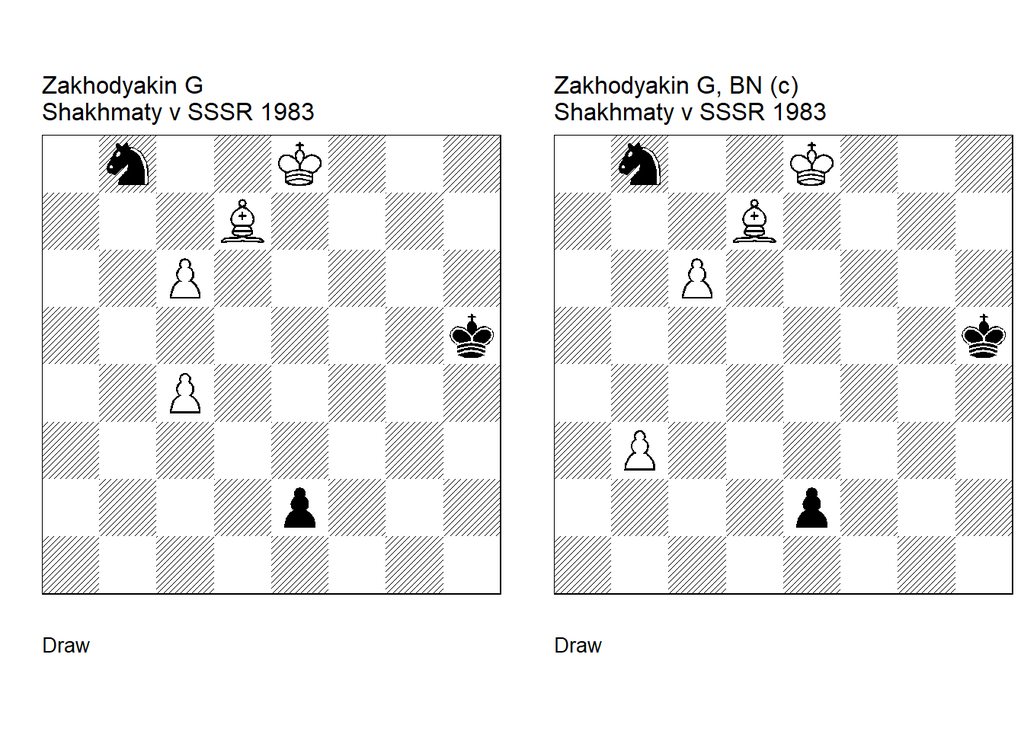

GBR: =0013.21e8h5 FEN: 1n2K3/3B4/2P5/7k/2P5/8/4p3/8 w - - 0 1

**Shakhmaty v SSSR/3. U3: Bogdanov=I Shakhmaty v SSSR/12 1983. 1. Bg4+! Kxg4 2. c7 e1=Q+ 3. Kf7 Qf1+** (3… Qf2+ 4. Kg8) **4. Kg7 Qa1+** (4… Nd7! cook IB 5. c8=Q Qf6+! 6. Kg8 (6. Kh7 Qe7+ 7. Kh6 Kf5 8. c5 (8. Qg8 Qh4+ 9. Kg7 Qf6+ 10. Kh7 Nf8+) 8… Qf7 9. Qc6 Qf8+ 10. Kh5 Qh8+ 11. Qh6 Nf6+) 6… Qe7 7. Kh8 Kf5! (7… Kg5? 8. Qa8 (8. c5? Nf6) (8. Qg8+? Kh6) 8… Qf6+ (8… Nf6 9. Qg2+ Kh6 10. Qh2+ (10. Qh3+? Nh5!) 10… Kg6 11. Qg3+ Kf7 12. Qg7+! ( 12. Qb8? Qd7!) ) 9. Kg8 Qg6+ 10. Kh8 Qh6+ 11. Kg8 Nf6+ 12. Kf7 Qg6+ 13. Ke6 Qf5+ 14. Ke7! (14. Kd6? Ne4+ 15. Kc7 Qe5+ 16. Kb6 Qc5+ 17. Ka6 Qa3+ 18. Kb7 Nc5+ 19. Kb8 Nd7+ 20. Kb7 Qf3+ 21. Ka7 Qf2+ 22. Kb7 Qg2+ 23. Ka7 Qa2+ 24. Kb7 Nc5+ 25. Kb8 Qh2+ 26. Ka7 Qc7+) 14… Qd7+ 15. Kf8 Qd6+ 16. Kf7 Qc7+ 17. Kf8) 8. c5 Kg5! 9. Qa8 Qf6+ 10. Kg8 Qg6+ 11. Kh8 Qh6+ 12. Kg8 Nf6+ 13. Kf7 Qg6+ 14. Ke6 Qf5+ 15. Ke7 (15. Kd6 Ne4+! 16. Kc7 Qe5+ 17. Kc8 Qe8+ 18. Kb7 Nxc5+ 19. Ka7 Qa4+ 20. Kb8 Qf4+ 21. Kc8 Qf8+) 15… Nd5+! 16. Kd6 Qf6+ 17. Kd7 Qe7+ 18. Kc6 Qe6+ 19. Kb7 Qd7+ 20. Ka6 Qa4+) (4… Nd7) (4… Qa1+) **5. Kg8 1/2-1/2**.

GBR: =0013.21e8h5 FEN: 1n2K3/3B4/2P5/7k/8/1P6/4p3/8 w - - 0 1

**correction: Neuenschwander=B beatochess 15/04/2024. 1. Bg4+! Kxg4 2. c7 e1=Q+ 3. Kf7 Qf1+** (3… Qf2+ 4. Kg8) **4. Kg7 Qa1+** (4… Nd7 5. c8=Q Qf6+ 6. Kg8 Qe7 7. Qc4+) **5. Kg8 1/2-1/2**.

### =3016.10b3f4 (1982). Cook? Version

Date: 2024, April 16

File: Zakhodyakin1982c.pgn

**Study no. 220** (Table 1 in beatochess-01)

Black’s **3… Nc4** is much more dangerous and requires precise White play. With this as the main line, the study is correct. The version is more parsimonious and interesting due to the fact that the black queen has the square h8 at her disposal.

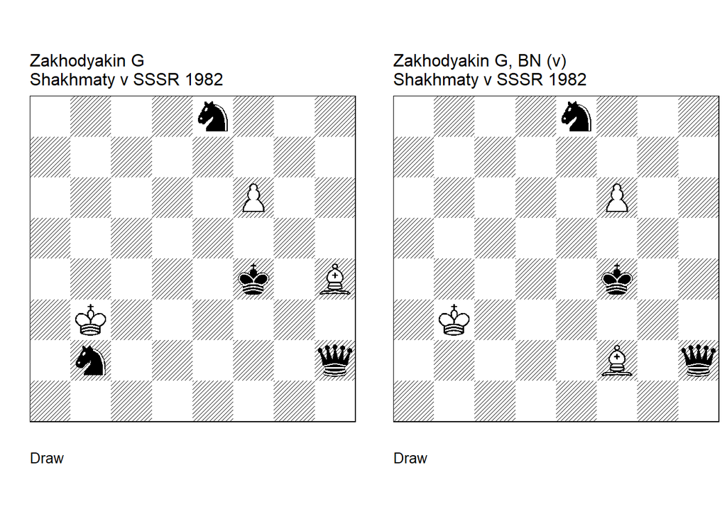

GBR: =3016.10b3f4 FEN: 4n3/8/5P2/8/5k1B/1K6/1n5q/8 w - - 0 1

**Shakhmaty v SSSR/9. U2: Beasley=J HHdbIII 20149 3-2-2002. Change main line: Neuenschwander=B beatochess 16/04/2024. 1. f7 Qh3+ 2. Bg3+!** (2. Kb4? Nd3+) (2. Ka2? Qe6+) **2… Qxg3+ 3. Ka2! Nf6** (3… Nc4 is much more dangerous main line? BN 4. f8=Q+ Ke4 5. Qxe8+ Kd3 6. Qe7! Kc3 (6… Qg8 7. Qb4 Qa8+ 8. Kb3 /b1 8… Nd2+ 9. Kb2 Qh8+ 10. Ka2 =) 7. Qe1+! Qxe1) **4. f8=Q Qc3 5. Qb8+** (5. Qd6+! cook JB ) (5. Qa3! cook JB ) **1/2-1/2**.

GBR: =3013.10b3f4 FEN: 4n3/8/5P2/8/5k2/1K6/5B1q/8 w - - 0 1

**version: Neuenschwander=B beatochess 16/04/2024. 1. f7 Qh3+** (1… Qh8 2. Bc5 Qh3+ 3. Kb4! (3. Kb2 Qg2+! 4. Kc1 (4. Ka3 Qa8+ 5. Kb2 Qb7+) 4… Qh1+ 5. Kb2 (5. Kd2 Qd5+) (5. Kc2 Qh7+) 5… Qb7+) ) **2. Bg3+!** (2. Kb4? Qh8 3. Bc5 Qb2+) **2… Qxg3+ 3. Ka4!** (3. Kb4? Qe1+) (3. Kc4? Nd6+) **1/2-1/2**.

### +0027.01c3e6 (1931). Correction

Date: 2024, April 19

File: Zakhodyakin1931b.pgn

**Study no. 19** (Table 1 in beatochess-01)

The prize winner seems hard to fix with the original material because two bishops vs. knight (and even a few pawns) will often be lost. The correcction requires quite a bit of additional material.

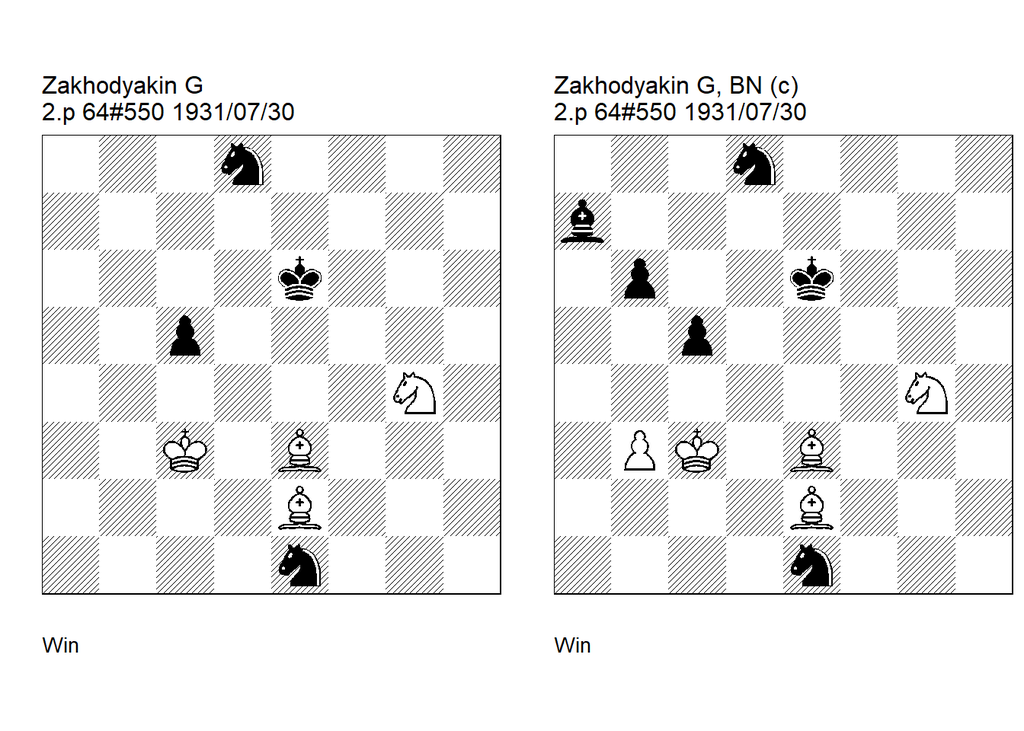

GBR: +0027.01c3e6 FEN: 3n4/8/4k3/2p5/6N1/2K1B3/4B3/4n3 w - - 0 1

**64=13-14 . U2: 64 Shakhmatnoye Obozrenye=9** (728) **5/1985 U1: Beasley=J HHdbIII 53843 3-2-2002. 1. Bd2!** (1. Bxc5! cook JB ) **1… Ng2 2. Bf1! Nf4!** (2… Nh4 3. Bg5 Kf5 4. Bxh4) (2… Kf5 3. Nh6+) **3. Bxf4 Kf5 4. Bc7** (4. Be3! cook 4… Kxg4 5. Bxc5) **4… Ne6 5. Ne3+!** (5. Nh6+? Kg6) **5… Ke4 6. Nd5! Kxd5 7. Bg2 1-0**.

GBR: +0057.12c3e6 FEN: 3n4/b7/1p2k3/2p5/6N1/1PK1B3/4B3/4n3 w - - 0 1

**correction: Neuenschwander=B beatochess 19/04/2024. 1. Bd2 Ng2 2. Bf1 Nf4** ( 2… Nh4 3. Bg5) (2… Kf5 3. Nh6+) (2… Nf4 3. Bxf4 Kf5 4. Bc7 Ne6 5. Ne3+ Ke4 6. Nd5 Kxd5 7. Bg2 ) **3. Bxf4 Kf5 4. Bc7 Ne6 5. Ne3+ Ke4 6. Nd5 Kxd5 7. Bg2 1-0**.

Date: 2024, April 19

File: Zakhodyakin1931c.pgn

**Study no. 25** (Table 1 in beatochess-01)

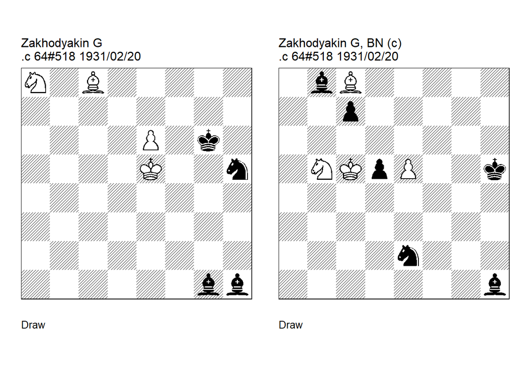

GBR: =0074.10e5g6 FEN: N1B5/8/4P1k1/4K2n/8/8/8/6bb w - - 0 1

**64=2-3 . U3: Afek=Y HHdbVI 6-8-2020. 1. e7 Nf6!** (1… Kf7 2. e8=Q+ Kxe8 3. Nc7+ Kd8 4. Bg4) **2. Nc7 Bh2+ 3. Ke6 Bxc7** (3… Be4! cook YA 4. e8=Q+ Nxe8 5. Nxe8 Bf5+ 6. Kd5 Bxc8) **4. e8=Q+ Nxe8 5. Kd7 Kf7 6. Bb7 Bxb7 1/2-1/2**.

GBR: =0074.12c5h5 FEN: 1bB5/2p5/8/1NKpP2k/8/8/4n3/7b w - - 0 1

**correction: Neuenschwander=B beatochess 19/04/2024. 1. e6 Ng3** (1… Kg6 2. Kc6 Kf6 3. Kd7 Be4 4. e7 Bg6 5. Bb7 Nf4 (5… d4 6. Be4 Bf7 7. Bd5) 6. Bc6 Bf5+ 7. Kd8 Ne6+ 8. Kc8 Nd4+ 9. Kb7 Nxb5 10. e8=N+ =) **2. e7** (2. Nxc7? Nf5! ( 2… Bxc7? 3. e7 Ne4+ 4. Kc6) 3. Nxd5 Bxd5 4. Kxd5 Ne7+ -/+) **2… Ne4+ 3. Kxd5** (3. Kc6 Nf6 4. Kb7 (4. Nd4 Ba7) 4… c6 5. Kxc6 j 5… Kg6 -/+) **3… Nf6+ 4. Ke6 Kg6 5. Nxc7!** (5. Bd7 Bd5+ 6. Ke5 c5+) **5… Bxc7** (5… Be4 6. Kd6! (6. e8=Q+? Nxe8 7. Nxe8 Bf5+ 8. Ke7 Bxc8 -/+) 6… Ne8+ 7. Kd7 Nxc7 8. e8=Q+ Nxe8 9. Kxe8) **6. e8=Q+! Nxe8 7. Kd7 Kf7 8. Bb7! Bxb7 1/2-1/2**.

### =4016.21a1c1 (1931). Correction

Date: 2024, April 20

File: Zakhodyakin1931d.pgn

**Study no. 16** (Table 1 in beatochess-01)

The correction of the prize winner is even shorter than the original, but it keeps the main ideas (bishop inference sacrifice and queen sacrifice leading to stalemate).

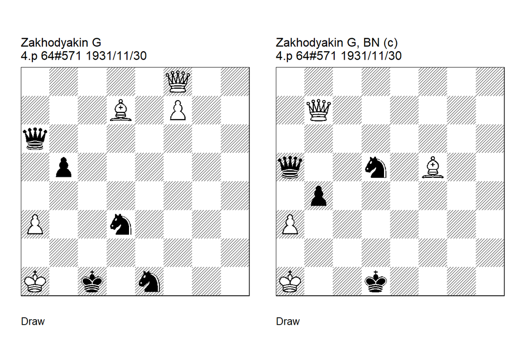

GBR: =4016.21a1c1 FEN: 5Q2/3B1P2/q7/1p6/8/P2n4/8/K1k1n3 w - - 0 1

**64=21-22 . U3: Beasley=J HHdbIII 53872 3-2-2002 U3: Haworth=G Bleicher=E HHdbIV 14339 1-11-2009. 1. Qc8+ Nc2+ 2. Qxc2+ Kxc2 3. f8=Q b4!** (3… Qa7! cook JB 4. Qc8+ Kd2) **4. Ba4+ Qxa4 5. Qxb4! Nxb4** (5… Qa8! cook GH/EB ) (5… Qa6! cook GH/EB ) (5… Qe8! cook GH/EB ) (5… Qc6! cook GH/EB ) (5… Qa7! cook GH/EB ) **1/2-1/2**.

GBR: =4013.11a1d1 FEN: 8/1Q6/8/q2n1B2/1p6/P7/8/K2k4 w - - 0 1

**correction: Neuenschwander=B beatochess 20/04/2024. 1. Bc2+! Kc1** (1… Kxc2 2. Qh7+ Kb3 (2… Kc3 3. Qh3+ Kc4 4. Kb2) 3. Qb1+ Kc4 4. Qe4+ Kc5 5. Qc2+ Kb5 6. Qd3+) **2. Ba4! Qxa4** (2… Qc5 3. Qg7) **3. Qxb4! Nxb4 1/2-1/2**.

### +0014.13e4a6 (1948). Correction

Date: 2024, April 22

File: Zakhodyakin1948b.pgn

**Study no. 69** (Table 1 in beatochess-01)

This study was quite difficult to fix, requiring quite a bit of additional material.

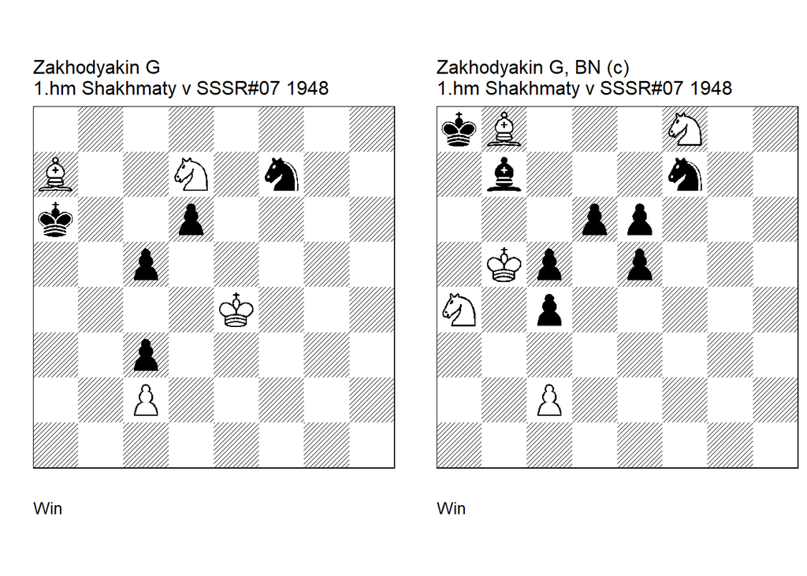

GBR: +0014.13e4a6 FEN: 8/B2N1n2/k2p4/2p5/4K3/2p5/2P5/8 w - - 0 1

**Shakhmaty v SSSR/3. U3:** (HHdbII 20443 1948) **U3: Paavilainen=J Suomen Tehtavaniekat=1 4-4-2008. 1. Bb8** (1. Bb6? Kb5 2. Kf5 Kc6 3. Kg6 Nh8+ 4. Kg7 Kxd7 5. Ba5 Ke6 6. Kxh8 d5! 7. Bxc3 d4 8. Be1 c4 9. Kg7 c3) **1… Kb7** (1… Kb5! cook 2. Kd5 Ng5 3. Nf6 (3. Bxd6 Nf3 4. Nxc5 Ne1 5. Ne4 Nxc2 6. Nxc3+ Ka5 7. Kc5 Na3 8. Bc7+ Ka6 9. Bf4 Ka5 10. Bc1 Nc2 11. Bd2 Na3) 3… Nf3 4. Ng4 Kb4! 5. Bxd6 Ka3 6. Bxc5+ Kb2 7. Ne3 Ne1 8. Kc4 Nxc2 9. Nd1+ Kc1 10. Nxc3 Kb2 ) **2. Kd5 Kc8 3. Kc6!** (3. Ke6? Ng5+ 4. Kxd6 Nf3) **3… Nd8+ 4. Kxd6 Kb7!** ( 4… Nb7+ 5. Ke7 Na5 6. Bf4! Nc6+! cook JP (6… Nc4 7. Bc1! Nd2 8. Nxc5 Nf3 9. Ne6) 7. Kd6 Nd4 8. Ne5! Nxc2 9. Kxc5 Na3! (9… Ne1? 10. Kd4 Nc2+ (10… c2 11. Bc1 Kc7 12. Ke4 Ng2 (12… Kd6 13. Ng6 Ke6 14. Nf4+) 13. Ng6 Kd7 14. Kf3 Ne1+ 15. Ke2 Ng2 16. Kf2) 11. Kxc3 Na3 12. Kb4 Nc2+ 13. Kc5! Kb7 14. Bd2 Ka6 15. Nf3 Na3 16. Nd4) 10. Nf3 Nb1 11. Ng5! Nd2 (11… c2? 12. Kb4 Kd7 13. Kb3 Ke7 14. Bc1 Kf6 15. Nf3 Kf5 16. Kxc2 Ke4 17. Ne1) 12. Kb4) **5. Ne5!** (5. Ke7? Nc6+) (5. Bc7? Nf7+) **5… Kxb8 6. Kd7! Nb7 7. Nc6+ Ka8 8. Ke6! c4 9. Kd5! 1-0**.

GBR: +0045.15b5a8 FEN: kB3N2/1b3n2/3pp3/1Kp1p3/N1p5/8/2P5/8 w - - 0 1

**correction: Neuenschwander=B beatochess 22/04/2024. 1. Nd7** ( Black has sufficient material for equality after 1. Bc7) **1… Bc8 2. Nab6+ Kb7 3. Nxc8 Kxc8 4. Kc6 Nd8+** (4… e4 5. Bc7) **5. Kxd6 Kb7** (5… Nb7+ 6. Kxe6 Na5 7. Bxe5) **6. Nxe5! Kxb8 7. Kd7 Nb7 8. Nc6+ Ka8 9. Kxe6 c3 10. Ke5! c4 11. Kd5 1-0**.

### +0310.10g8a7 (1962). Correction

Date: 2024, April 22

File: Zakhodyakin1962a.pgn

**Study no. 92** (Table 1 in beatochess-01)

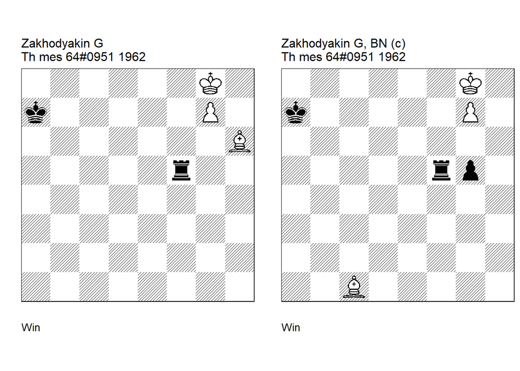

GBR: +0310.10g8a7 FEN: 6K1/k5P1/7B/5r2/8/8/8/8 w - - 0 1

**Th mes 64=28 Th mes 64/10-12. U2: Th mes 64=30 4-6/1963. 1. Kh8 Rb5 2. Be3+** (2. g8=Q! cook Rb8 3. Bf8) **2… Ka8 3. Bc5 Rb8+ 4. Bf8 Rb1 5. g8=Q Rh1+ 6. Bh6+ 1-0**.

GBR: +0310.11g8a7 FEN: 6K1/k5P1/8/5rp1/8/8/8/2B5 w - - 0 1

**correction: Neuenschwander=B beatochess 22/04/2024. 1. Kh8 Rb5 2. Be3+ Ka8 3. Bc5 Rb8+ 4. Bf8 Rb1 5. g8=Q** (5. Bd6? Rh1+ 6. Kg8 Rh6 7. Kf7 Rh7) **5… Rh1+ 6. Bh6+ 1-0**.

### =0002.03g5g1 (1962). Correction

Date: 2024, April 22

File: Zakhodyakin1962b.pgn

**Study no. 91** (Table 1 in beatochess-01)

The correction uses two additional pawns.

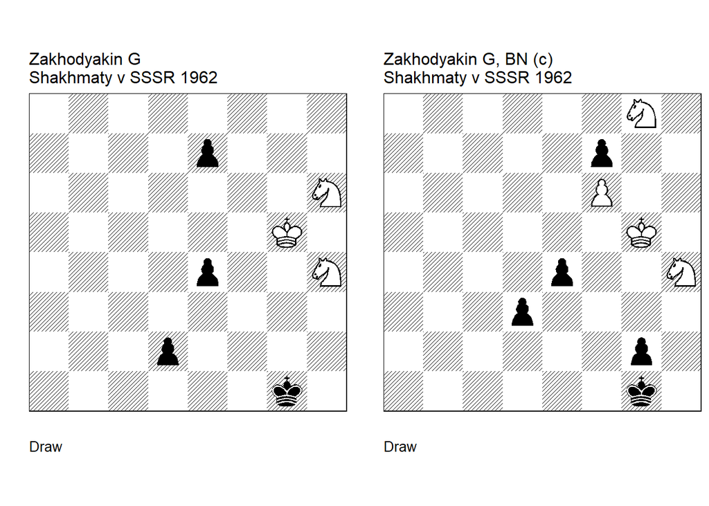

GBR: =0002.03g5g1 FEN: 8/4p3/7N/6K1/4p2N/8/3p4/6k1 w - - 0 1

**Shakhmaty v SSSR/10. U3: Lafora=C Dos Caballos en Combate 375 1965. 1. Ng4 d1=Q 2. Ng2! Qd5+ 3. Kh4 e5** ( 3… Qf5! cook CL 4. N2e3 Qg6! 5. Kg3 Qg5 6. Kh3 Qh5+ 7. Kg3 e5) **4. N2e3 1/2-1/2**.

GBR: =0002.14g5g1 FEN: 6N1/5p2/5P2/6K1/4p2N/3p4/6p1/6k1 w - - 0 1

**correction: Neuenschwander=B beatochess 22/04/2024. 1. Nh6 d2 2. Ng4 d1=Q 3. Nxg2! Qd5+** ( 3… Kxg2 4. Ne3+) **4. Kh4!** (4. Kh6? Qf5 (4… Qd2+? 5. N2e3) ) (4. Kf4 Qd6+) **4… Qf5 5. N2e3 1/2-1/2**.

### =0305.01f4b1 (1965). Correction

Date: 2024, April 23

File: Zakhodyakin1965a.pgn

**Study no. 96** (Table 1 in beatochess-01)

The study can be saved with the same material.

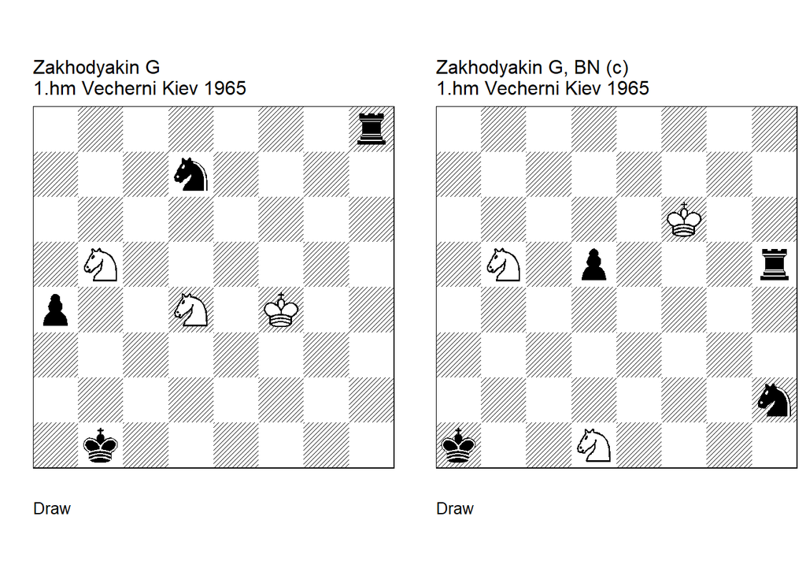

GBR: =0305.01f4b1 FEN: 7r/3n4/8/1N6/p2N1K2/8/8/1k6 w - - 0 1

**EG 00057. U2: Garcia=M EG=173 7/2008. 1. Nc3+ Ka1 2. Nxa4 Rc8 3. Ke4** (3. Nb3+! cook MG 3… Ka2 4. Nd2 Ka3 5. Nc3) **3… Rc4 4. Nc5 Nxc5+ 5. Kd5 Rc3 6. Ne2 Re3 7. Nd4 Rc3 8. Ne2 Rc2 9. Nd4 Rc1 10. Ne2 Re1 11. Nd4 1/2-1/2**.

GBR: =0305.01f6a1 FEN: 8/8/5K2/1N1p3r/8/8/7n/k2N4 w - - 0 1

**correction: Neuenschwander=B beatochess 23/04/2024. 1. Nd4** (1. Ndc3? Kb2 2. Ke6 d4) (1. Ke6? Nf3) **1… Ng4+** (1… Rh3 2. Ne3 Nf3 3. Ne6) **2. Ke6 Rh3 3. Kxd5 Rd3 4. Ne3! Nxe3+ 5. Ke4 Rc3 6. Nb5 Rb3 7. Nd4 Ra3 8. Nb5 Ra5 9. Nd4 Ra3 10. Nb5 Rb3 11. Nd4 Rc3 12. Nb5 Rc5 13. Nd4 Rc3 14. Nb5 1/2-1/2**.

### =0510.12d1h6 (1965). Correction

Date: 2024, April 23

File: Zakhodyakin1965b.pgn

**Study no. 97** (Table 1 in beatochess-01)

One of Zakhodyakin’s most spectacular positional draws. The correction with the additional white h-pawn adds more content.

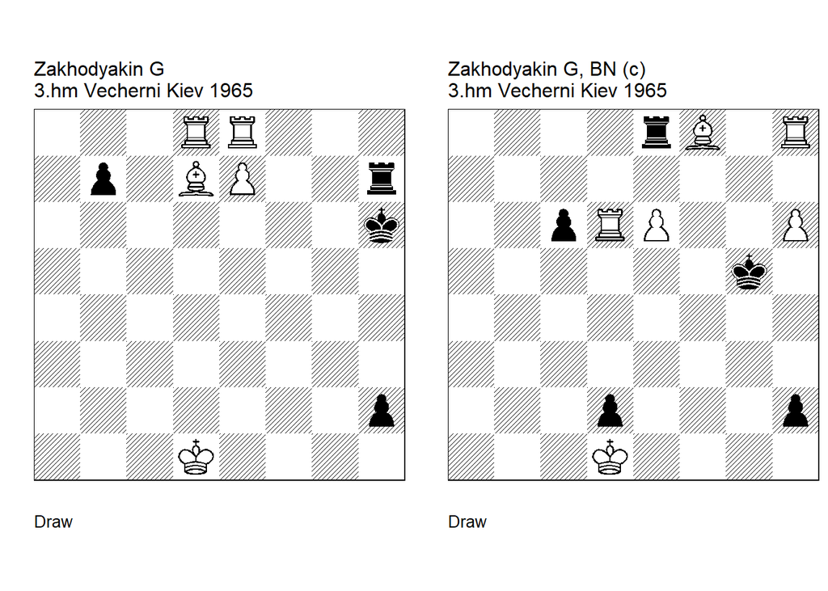

GBR: =0510.12d1h6 FEN: 3RR3/1p1BP2r/7k/8/8/8/7p/3K4 w - - 0 1

**EG 00059. U1: Veitch=W EG=3 1/1966 U2: Aloni=H Shahmat 1966. 1. Bc6** (1. Kc2! cook WV 1… h1=Q 2. Bb5 Qe4+ 3. Kb3 Rxe7 4. Rxe7 Qxe7 5. Rd5) **1… bxc6 2. Rd6+ Kh5 3. Rd5+** (3. Re6! cook HA 3… h1=Q+ 4. Re1 Qd5+ 5. Kc2 Kh6 6. Re2) **3… cxd5 4. Rg8 h1=Q+ 5. Kd2 Qh2+ 6. Kd1 1/2-1/2**.

GBR: =0510.23d1g5 FEN: 4rB1R/8/2pRP2P/6k1/8/8/3p3p/3K4 w - - 0 1

**correction: Neuenschwander=B beatochess 23/04/2024. 1. Be7+! Rxe7 2. Rg8+ Kh5** (2… Kf6 3. Rf8+ Ke5 4. Rf1 Kxd6 5. Rh1) (2… Kh4 3. Rd4+) **3. Rd5+! cxd5 4. h7! h1=Q+ 5. Kxd2 Qh2+ 6. Kd1 Qh1+ 7. Kd2 Rxh7 8. e7 Qh2+ 9. Kd1 Qh1+ 10. Kd2 1/2-1/2**.